# Case Study 2

Section 403, Group 5:

Gregory Asamoah

Emil Ramos

Brian Coari

December 03, 2017

# Install necessary packages if not installed:

```r
# Find all packages that are not in the list of installed packages and install packages used if not yet installed
list.of.packages <- c('xml2','rvest', 'dplyr', 'tidyr', 'DT','readr', 'ggplot2','plyr','reshape2')
new.packages <- list.of.packages[!(list.of.packages %in% installed.packages()[,"Package"])]
if(length(new.packages)) install.packages(new.packages)

library('xml2')
library('rvest')
library('dplyr')
library('tidyr')
library('DT')
library('readr')
library('ggplot2')
library('reshape2')
library('plyr')
```

## Introduction

Greetings Nintendo Marketing Team,

Our company, LazyLife Inc., is an expert an analyzing procrastination data and Life Satisfaction statistics for countries across the world. We have access to thousands of observations that give us insight into who in world considers themselves a procrastinator, and who is satisfied with their life. LazyLife Inc. differentiates itself from our competition by also including exerpts from the Human Development Index (HDI) to see which countries are happy, lazy, and developed.

Procrastination can basically be defined as the action of delaying or postponing task that needs to be done. It’s an inevitable part of human life and our various daily activities that are time bound. It has implications for performance, prevents you from meeting deadlines, can lead to disorganization and becomes the major reason for failure on time bound projects and daily life activities. However, during this procrastination, what are people doing? I’ll tell you what I’m doing… playing Nintendo!

We believe that by leveraging our data, Nintendo will be able to target the laziest and most developed countries in order to get the most value for your marketing dollars. In addition, adding in life satisfaction will assure you that your customers are happy, wealthy, lazy, and ready to consume. This is what we feel is your ideal market, and will allow your product to thrive in perhaps new and lucrative markets.

If you purchase the results of our analysis we will provide you with quarterly updates on these markets so you can adjust and continue to be most effective in your marketing and advertising.

Thank you,

Brian Coari, Gergory Asamoah, and Emil Ramos

LazyLife Inc.

Email: datascience@lazylife.com

Phone: (555) 867-5309

## Code Book for the raw Data

# Data Set Code Book: Procrastination

# November 25, 2017

# The Procrastination csv data set contains 4264 observations and 61 variables

```r
stringsAsFactors=FALSE

Procrastination_Raw_Data <- read.csv(".\\Data\\Procrastination.csv",header=TRUE, sep=",", fileEncoding="UTF-8-BOM")

#class(Procrastination_Raw_Data)
sapply(Procrastination_Raw_Data, class)
```

```
##                                                                                                                      Age
##                                                                                                                "numeric"
##                                                                                                                   Gender
##                                                                                                                 "factor"
##                                                                                                                     Kids
##                                                                                                                 "factor"
##                                                                                                                      Edu
##                                                                                                                 "factor"
##                                                                                                              Work.Status
##                                                                                                                 "factor"
##                                                                                                            Annual.Income
##                                                                                                                "integer"
##                                                                                                       Current.Occupation
##                                                                                                                 "factor"
##                                                                             How.long.have.you.held.this.position...Years
##                                                                                                                "numeric"
##                                                                            How.long.have.you.held.this.position...Months
##                                                                                                                "integer"
##                                                                                                           Community.size
##                                                                                                                 "factor"
##                                                                                                     Country.of.residence
##                                                                                                                 "factor"
##                                                                                                           Marital.Status
##                                                                                                                 "factor"
##                                                                                                           Number.of.sons
##                                                                                                                 "factor"
##                                                                                                      Number.of.daughters
##                                                                                                                "integer"
##                                   X.DP.1..I.waste.a.lot.of.time.on.trivial.matters.before.getting.to.the.final.decisions
##                                                                                                                "integer"
##                                                              X.DP.2..Even.after.I.make.a.decision.I.delay.acting.upon.it
##                                                                                                                "integer"
##                                                                   X.DP.3..I.don.t.make.decisions.unless.I.really.have.to
##                                                                                                                "integer"
##                                                                     X.DP.4..I.delay.making.decisions.until.it.s.too.late
##                                                                                                                "integer"
##                                                                   X.DP.5..I.put.off.making.decisions.until.it.s.too.late
##                                                                                                                "integer"
##                                                                                          X.AIP.1..I.pay.my.bills.on.time
##                                                                                                                "integer"
```

[output cut: 67 more lines]

```
##                                                                                                                "integer"
##                                                                      X.SWLS.1..In.most.ways.my.life.is.close.to.my.ideal
##                                                                                                                "integer"
##                                                                         X.SWLS.2.The.conditions.of.my.life.are.excellent
##                                                                                                                "integer"
##                                                                                   X.SWLS.3..I.am.satisfied.with.my.life.
##                                                                                                                "integer"
##                                                       X.SWLS.4..So.far.I.have.gotten.the.important.things.I.want.in.life
##                                                                                                                "integer"
##                                                    X.SWLS.5..If.I.could.live.my.life.over..I.would.change.almost.nothing
##                                                                                                                "integer"
##                                                                               Do.you.consider.yourself.a.procrastinator.
##                                                                                                                 "factor"
##                                                                                 Do.others.consider.you.a.procrastinator.
##                                                                                                                 "factor"
```

```r
#summary(Procrastination_Raw_Data)
```

## Clean your Raw Data

```r
# a Read the csv into R and take a look at the data set. Output how many rows and columns the data.frame is.

str(Procrastination_Raw_Data)
```

```
## 'data.frame':    4264 obs. of  61 variables:
##  $ Age                                                                                                                     : num  67.5 45 19 37.5 28 23 67.5 37.5 24 45 ...
##  $ Gender                                                                                                                  : Factor w/ 3 levels "","Female","Male": 3 3 2 3 2 2 2 3 2 3 ...
##  $ Kids                                                                                                                    : Factor w/ 3 levels "","No Kids","Yes Kids": 3 3 2 3 2 2 2 2 2 3 ...
##  $ Edu                                                                                                                     : Factor w/ 9 levels "","deg","dip",..: 8 2 3 8 2 2 8 4 8 8 ...
##  $ Work.Status                                                                                                             : Factor w/ 7 levels "","0","full-time",..: 5 4 6 3 3 3 4 4 3 3 ...
##  $ Annual.Income                                                                                                           : int  25000 35000 NA 45000 35000 15000 NA 10000 250000 87500 ...
##  $ Current.Occupation                                                                                                      : Factor w/ 676 levels "","'Utterly shiftless arts student'... at p",..: 1 1 1 1 1 1 1 1 1 1 ...
##  $ How.long.have.you.held.this.position...Years                                                                            : num  9.0 1.5e-19 0.0 1.4e+01 1.0 ...
##  $ How.long.have.you.held.this.position...Months                                                                           : int  0 0 0 0 0 0 0 0 0 0 ...
##  $ Community.size                                                                                                          : Factor w/ 10 levels "","0","8","Large-City",..: 4 10 5 5 10 9 5 10 10 10 ...
##  $ Country.of.residence                                                                                                    : Factor w/ 94 levels "","0","Afghanistan",..: 31 15 25 26 26 26 60 88 88 73 ...
##  $ Marital.Status                                                                                                          : Factor w/ 7 levels "","0","Divorced",..: 3 4 6 4 6 6 3 6 6 4 ...
##  $ Number.of.sons                                                                                                          : Factor w/ 9 levels "","0","10","3",..: 2 9 2 2 2 2 2 2 2 8 ...
##  $ Number.of.daughters                                                                                                     : int  5 1 0 1 0 0 0 0 0 0 ...
```

[output cut: 47 more lines]

```r
# checking for Null values in the data set
anyNA(Procrastination_Raw_Data)
```

```
## [1] TRUE
```

```r
#view its class
class(Procrastination_Raw_Data)
```

```
## [1] "data.frame"
```

```r
# View its dimension
dim(Procrastination_Raw_Data)
```

```
## [1] 4264   61
```

```r
# look at the column names
names(Procrastination_Raw_Data)
```

```
##  [1] "Age"
##  [2] "Gender"
##  [3] "Kids"
##  [4] "Edu"
##  [5] "Work.Status"
##  [6] "Annual.Income"
##  [7] "Current.Occupation"
##  [8] "How.long.have.you.held.this.position...Years"
##  [9] "How.long.have.you.held.this.position...Months"
## [10] "Community.size"
## [11] "Country.of.residence"
## [12] "Marital.Status"
## [13] "Number.of.sons"
## [14] "Number.of.daughters"
## [15] "X.DP.1..I.waste.a.lot.of.time.on.trivial.matters.before.getting.to.the.final.decisions"
```

[output cut: 46 more lines]

```r
#structure of the data
glimpse(Procrastination_Raw_Data)
```

```
## Observations: 4,264
## Variables: 61
## $ Age                                                                                                                      <dbl> ...
## $ Gender                                                                                                                   <fctr> ...
## $ Kids                                                                                                                     <fctr> ...
## $ Edu                                                                                                                      <fctr> ...
## $ Work.Status                                                                                                              <fctr> ...
## $ Annual.Income                                                                                                            <int> ...
## $ Current.Occupation                                                                                                       <fctr> ...
## $ How.long.have.you.held.this.position...Years                                                                             <dbl> ...
## $ How.long.have.you.held.this.position...Months                                                                            <int> ...
## $ Community.size                                                                                                           <fctr> ...
## $ Country.of.residence                                                                                                     <fctr> ...
## $ Marital.Status                                                                                                           <fctr> ...
## $ Number.of.sons                                                                                                           <fctr> ...
```

[output cut: 48 more lines]

```r
#view summary
summary(Procrastination_Raw_Data)
```

```
##       Age           Gender           Kids           Edu
##  Min.   : 7.50         :  70           :   4   deg    :1199
##  1st Qu.:28.00   Female:2408   No Kids :2901   ma     :1098
##  Median :32.50   Male  :1786   Yes Kids:1359   ltuni  : 812
##  Mean   :37.43                                 phd    : 609
##  3rd Qu.:45.00                                 dip    : 205
##  Max.   :80.00                                 high   : 122
##  NA's   :71                                    (Other): 219
##      Work.Status   Annual.Income            Current.Occupation
##            : 111   Min.   :     0                    :2162
##  0         :   2   1st Qu.: 15000   0                : 488
##  full-time :2266   Median : 45000   please specify   : 217
##  part-time : 477   Mean   : 58916    teacher         :  74
##  retired   : 175   3rd Qu.: 67500   college professor:  43
##  student   : 971   Max.   :250000   engineer         :  32
##  unemployed: 262   NA's   :548      (Other)          :1248
##  How.long.have.you.held.this.position...Years
##  Min.   :  0.00
##  1st Qu.:  0.00
##  Median :  2.00
##  Mean   : 14.15
##  3rd Qu.:  6.00
##  Max.   :999.00
##  NA's   :94
##  How.long.have.you.held.this.position...Months      Community.size
##  Min.   : 0.000                                Large-City  :876
##  1st Qu.: 0.000                                Village     :830
##  Median : 0.000                                Medium-Sized:669
##  Mean   : 1.793                                Small Town  :655
##  3rd Qu.: 3.000                                Large Town  :466
##  Max.   :11.000                                Small City  :311
##  NA's   :6                                     (Other)     :457
##      Country.of.residence   Marital.Status Number.of.sons
##  United States :2893               : 174   0      :3272
##  Canada        : 250      0        :   6   Male   : 613
##  0             : 233      Divorced : 367   Female : 274
##  United Kingdom: 184      Married  :1599   3      :  69
##  Australia     : 104      Separated:  88   4      :  23
##  India         :  78      Single   :1963   5      :   7
##  (Other)       : 522      Widowed  :  67   (Other):   6
```

[output cut: 369 more lines]

```
##     :  14
##  no : 565
##  yes:3685
##
##
##
##
##  Do.others.consider.you.a.procrastinator.
##     :  42
##  0  :   1
##  4  :   8
##  no :1652
##  yes:2561
##
##
```

```r
# b The column names are either too much or not enough. Change the column names so that they do not have spaces, underscores, slashes, and the like. All column names should be under 12 characters. Make sure you're updating your codebook with information on the tidied data set as well.

#renaming the columns

names(Procrastination_Raw_Data)[5:61] = c("WorkStatus","Income","Occupation","PositionYrs","PositionMnth","CommSize","Country","MaritalStatus","NumofSons","NumofDaughters","XDP1","XDP2","XDP3","XDP4","XDP5","XAIP1","XAIP2","XAIP3","XAIP4","XAIP5","XAIP6","XAIP7","XAIP8","XAIP9","XAIP10","XAIP11","XAIP12","XAIP13","XAIP14","XAIP15","XGP1","XGP2","XGP3","XGP4","XGP5","XGP6","XGP7","XGP8","XGP9","XGP10","XGP11","XGP12","XGP13","XGP14","XGP15","XGP16","XGP17","XGP18","XGP19","XGP20","XSWLS1","XSWLS2","XSWLS3","XSWLS4","XSWLS5","Yourself","Others")


# c Some columns are, due to Qualtrics, malfunctioning. Prime examples are the following columns: "How long have you held this position?: Years", Country of residence, Number of sons, and Current Occupation.

# i Some have impossible data values. Detail what you are doing to fix these columns in the raw data and why. It's a judgment call for each, but explain why. For example, most people have not been doing anything for over 100 years. For the "Years" columns, round to the nearest integer.

#Data in the PostionYrs column that is 999 years or blank we will omit in our analysis, since 999 years is impossible and blank values are bad data.
#Omitting the rows is better than assuming a different value, and we have enough data with valid values to complete our analysis.
Procrastination_Raw_Data <- Procrastination_Raw_Data[which(Procrastination_Raw_Data$PositionYrs != ""),]
Procrastination_Raw_Data <- Procrastination_Raw_Data[which(Procrastination_Raw_Data$PositionYrs != 999),]
Procrastination_Raw_Data$PositionYrs <- round(Procrastination_Raw_Data$PositionYrs,0)

#Note that the data frame has 61 columns and 4264 rows and some of the columns have Null values and impossible data values. E.g People doing nothing over 100 years might be dead and must be removed from the dataset
#glimpse(Procrastination_Raw_Data)

# ii Somehow, "Number of sons" was labeled with Male (1) and Female (2). Change these incorrect labels back to integers.
Procrastination_Raw_Data <- Procrastination_Raw_Data[which(Procrastination_Raw_Data$NumofSons == "Male"),]
Procrastination_Raw_Data$NumofSons[which(Procrastination_Raw_Data$NumofSons == "Male")] <- "1"
Procrastination_Raw_Data$NumofSons[which(Procrastination_Raw_Data$NumofSons == "Female")] <- "2"
Procrastination_Raw_Data$NumofSons <- as.integer(Procrastination_Raw_Data$NumofSons)

# iii There are no "0" country of residences. Treat this as missing.
Procrastination_Raw_Data$Country[which(Procrastination_Raw_Data$Country == "0")] <- NA


# iv Current Occupation has no "please specify" or "0." Treat them as missing. Some jobs are quite similar. Use judgment calls to make overwrite them into the same category. It does not have to be 100% accurate, but right now "ESL Teacher" would not be counted as "teacher" if there were unique counts.
Procrastination_Raw_Data$Occupation[which(Procrastination_Raw_Data$Occupation == "0")] <- NA
Procrastination_Raw_Data$Occupation[which(Procrastination_Raw_Data$Occupation == "please specify")] <- NA

# d Make sure your columns are the proper data types (i.e., numeric, character, etc.). If they are incorrect, convert them.

#Reclassifying variables to their logical types
#The "Yourself" and "Others" fields could be boolean, but there are some bad values in Others so we're just proceeding as characters for now, we only lose a slight performance gain given the size of our data.
Procrastination_Raw_Data$Gender <- as.character(Procrastination_Raw_Data$Gender)
Procrastination_Raw_Data$Kids <- as.character(Procrastination_Raw_Data$Kids)
Procrastination_Raw_Data$Edu <- as.character(Procrastination_Raw_Data$Edu)
Procrastination_Raw_Data$WorkStatus <- as.character(Procrastination_Raw_Data$WorkStatus)
Procrastination_Raw_Data$Occupation <- as.character(Procrastination_Raw_Data$Occupation)
Procrastination_Raw_Data$PositionYrs <- as.integer(Procrastination_Raw_Data$PositionYrs)
Procrastination_Raw_Data$CommSize <- as.character(Procrastination_Raw_Data$CommSize)
Procrastination_Raw_Data$Country <- as.character(Procrastination_Raw_Data$Country)
Procrastination_Raw_Data$MaritalStatus <- as.character(Procrastination_Raw_Data$MaritalStatus)
Procrastination_Raw_Data$Yourself <- as.character(Procrastination_Raw_Data$Yourself)
Procrastination_Raw_Data$Others <- as.character(Procrastination_Raw_Data$Others)


# e Each variable that starts with either DP, AIP, GP, or SWLS is an individual item on a scale. For example, DP 1 through DP 5 are five different questions on the Decision Procrastination Scale. I've reverse-scored them for you already, but you should create a new column for each of them with their mean. To clarify, you'll need a DPMean column, an AIPMean column, a GPMean column, and a SWLSMean column. This represents the individual's average decisional procrastination (DP), procrastination behavior (AIP), generalized procrastination (GP), and life satisfaction (SWLS).

#Grab average of all the  DP, AIP, GP, and SWLS fields in a simple and readable way, summing and dividing
Procrastination_Raw_Data$DP_Mean <- mean(c(Procrastination_Raw_Data$XDP1,Procrastination_Raw_Data$XDP2,Procrastination_Raw_Data$XDP3,Procrastination_Raw_Data$XDP4,Procrastination_Raw_Data$XDP5))

Procrastination_Raw_Data$DP_Mean <- (Procrastination_Raw_Data$XDP1 + Procrastination_Raw_Data$XDP2 + Procrastination_Raw_Data$XDP3 + Procrastination_Raw_Data$XDP4 + Procrastination_Raw_Data$XDP5)/5

Procrastination_Raw_Data$AIP_Mean <- (Procrastination_Raw_Data$XAIP1 + Procrastination_Raw_Data$XAIP2 + Procrastination_Raw_Data$XAIP3 + Procrastination_Raw_Data$XAIP4 + Procrastination_Raw_Data$XAIP5 + Procrastination_Raw_Data$XAIP6 + Procrastination_Raw_Data$XAIP7 + Procrastination_Raw_Data$XAIP8 + Procrastination_Raw_Data$XAIP9 + Procrastination_Raw_Data$XAIP10 + Procrastination_Raw_Data$XAIP11 + Procrastination_Raw_Data$XAIP12 + Procrastination_Raw_Data$XAIP13 + Procrastination_Raw_Data$XAIP14 + Procrastination_Raw_Data$XAIP15)/15

Procrastination_Raw_Data$GP_Mean <- (Procrastination_Raw_Data$XGP1 + Procrastination_Raw_Data$XGP2 + Procrastination_Raw_Data$XGP3 + Procrastination_Raw_Data$XGP4 + Procrastination_Raw_Data$XGP5 + Procrastination_Raw_Data$XGP6 + Procrastination_Raw_Data$XGP7 + Procrastination_Raw_Data$XGP8 + Procrastination_Raw_Data$XGP9 + Procrastination_Raw_Data$XGP10 + Procrastination_Raw_Data$XGP11 + Procrastination_Raw_Data$XGP12 + Procrastination_Raw_Data$XGP13 + Procrastination_Raw_Data$XGP14 + Procrastination_Raw_Data$XGP15 + Procrastination_Raw_Data$XGP16 + Procrastination_Raw_Data$XGP17 + Procrastination_Raw_Data$XGP18 + Procrastination_Raw_Data$XGP19 + Procrastination_Raw_Data$XGP20 )/20

Procrastination_Raw_Data$SWLS_Mean <- (Procrastination_Raw_Data$XSWLS1 + Procrastination_Raw_Data$XSWLS2 + Procrastination_Raw_Data$XSWLS3 + Procrastination_Raw_Data$XSWLS4 + Procrastination_Raw_Data$XSWLS5)/5
```

## Scrape the Human Development Index tables online

```r
# (https://en.wikipedia.org/wiki/List_of_countries_by_Human_Development_Index#Complete_list_of_countries). Read what it is, because you'll have to explain it to your clients. BIG TIP: This one's going to be weird looking-it's real scraping. Make sure you're looking between the webpage and R while you do this to find your footing. Unit 9's HW might help.

# a You will notice there are several sections, but you should only worry about the Complete List of Countries section of this Wikipedia entry. There are 8 tables in this section, but you should pull these eight, clean them as to be usable, and then find a way to bind them into one singular table. You only need Country and 2016 Estimates for 2015 (you can call this HDI) columns for the final table.

url <- 'https://en.wikipedia.org/wiki/List_of_countries_by_Human_Development_Index#Complete_list_of_countries'

#Read the webpage from the URL
hdiWebpage <- read_html(url)

#Grab all the table nodes from the page
hdiNodes <- html_nodes(hdiWebpage, "table")

#Convert the nodes to HTML tables
hdiTables <- html_table(hdiNodes, fill=TRUE)

#trial and error to find the right 8 tables
hdiDataFrame1 <- data.frame(hdiTables[4])
hdiDataFrame2 <- data.frame(hdiTables[5])
hdiDataFrame3 <- data.frame(hdiTables[7])
hdiDataFrame4 <- data.frame(hdiTables[8])
hdiDataFrame5 <- data.frame(hdiTables[10])
hdiDataFrame6 <- data.frame(hdiTables[11])
hdiDataFrame7 <- data.frame(hdiTables[13])
hdiDataFrame8 <- data.frame(hdiTables[14])

#The first data frame calls the Country field "Country.Territory", but the other 7 call this column "Country"
#Changing the first data frame for consistency and easy binding
colnames(hdiDataFrame1)[colnames(hdiDataFrame1)=="Country.Territory"] <- "Country"

#binding all of the data frames
hdiDataFrame_all <- bind_rows(hdiDataFrame1,hdiDataFrame2,hdiDataFrame3,hdiDataFrame4,hdiDataFrame5,hdiDataFrame6,hdiDataFrame7,hdiDataFrame8)

#Removing all header rows from the table, header rows all store the name "Rank" in the Rank.1 field
hdiDataFrame_all <- hdiDataFrame_all[which(hdiDataFrame_all$Rank.1 != "Rank"),]

#Removing all but the necessary "Country" and "HDI" fields
hdiDataFrame_all$Rank <- NULL
hdiDataFrame_all$Rank.1 <- NULL
hdiDataFrame_all$HDI.1 <- NULL

#converting HDI to numeric since it fits the data better than chr
hdiDataFrame_all$HDI <- as.numeric(hdiDataFrame_all$HDI)

# b Create a new column for this final scraped table which categories the Countries like the original page (Very high human development, High human development, Medium human development, Low human development). After these categories, output a csv file of this table to your repository.

#Initializing the new column to "Unknown"
hdiDataFrame_all$Development.Category <- "Unknown"

#Classifying the new variable based on the value of HDI
#Any Country with an HDI of between .8 and 1, inclusive, is considered "Very high human development"
hdiDataFrame_all$Development.Category[which(hdiDataFrame_all$HDI >= .8 & hdiDataFrame_all$HDI <= 1)] <- "Very high human development"

#Any Country with an HDI of between .7 inclusive and .8 exclusive is considered "High human development"
hdiDataFrame_all$Development.Category[which(hdiDataFrame_all$HDI >= .7 & hdiDataFrame_all$HDI < .8)] <- "High human development"

#Any Country with an HDI of between .55 inclusive and .7 exclusive is considered "Medium human development"
hdiDataFrame_all$Development.Category[which(hdiDataFrame_all$HDI >= .55 & hdiDataFrame_all$HDI < .7)] <- "Medium human development"

#Any Country with an HDI of between 0 inclusive and .55 exclusive is considered "Low human development"
hdiDataFrame_all$Development.Category[which(hdiDataFrame_all$HDI >= 0 & hdiDataFrame_all$HDI < .55)] <- "Low human development"


# c Merge this data frame to the Country of Residence column of Procrastination.csv so that your data now has an HDI column and HDI categories (Very high human development, etc.).

#After the first merge and verification, these countries did not have a match:
# Antigua (Corrected by renaming "Antigua and Barbuda" to "Antigua" in the merged HDI data)
# Bermuda
# Columbia
# Guam
# Isreal (Corrected with renaming to "Israel" below, the proper spelling)
# Macao
# Puerto Rico
# Taiwan
# Yugoslavia

#These 5 lines could go in data cleanup:
Procrastination_Raw_Data <- Procrastination_Raw_Data[which(Procrastination_Raw_Data$Country != ""),]
Procrastination_Raw_Data <- Procrastination_Raw_Data[which(Procrastination_Raw_Data$Country != "0"),]
Procrastination_Raw_Data <- Procrastination_Raw_Data[which(!is.na(Procrastination_Raw_Data$Country)),]
#changed to match merged HDI data
Procrastination_Raw_Data$Country[which(Procrastination_Raw_Data$Country == "Isreal")] <- "Israel"

#changed to match Procrastination
hdiDataFrame_all$Country[which(hdiDataFrame_all$Country == "Antigua and Barbuda")] <- "Antigua"

#Merge the data and keep all Procrastination, even if there is no match for HDI Data. We can revisit this later if it causes problems
ProcrastinationHdiData <- merge(Procrastination_Raw_Data,hdiDataFrame_all,by.x = "Country", by.y = "Country",all.x=TRUE)

ProcrastinationHdiDataErrors <- ProcrastinationHdiData[which(is.na(ProcrastinationHdiData$HDI)),]

#Rows with these countries listed in ProcrastinationData still have NA for their HDI scores and categories, and I am not sure what to do about it since they are legitimately not countries for which HDI is listed on this page for 2016:
# Bermuda
# Columbia
# Guam
# Macao
# Puerto Rico
# Taiwan
# Yugoslavia
```

## Preliminary Analysis

```r
# a Remove all observations where the participant is under age 18. No further analysis of underage individuals is permitted by your client. Remove any other age outliers as you see fit, but be sure to tell what you’re doing and why.
ProcrastinationHdiData_18_or_older <- ProcrastinationHdiData[which(ProcrastinationHdiData$Age >= 18),]

# b Please provide (in pretty-fied table format or similar), descriptive statistics on Age, Income, HDI, and the four mean columns (DP, etc.).

#separate the summary from its class structure to be stored in a data frame
dfAgeSummary<- data.frame(unclass(summary(ProcrastinationHdiData_18_or_older$Age)), check.names = FALSE)
dfIncomeSummary<- data.frame(unclass(summary(ProcrastinationHdiData_18_or_older$Income)), check.names = FALSE)
dfHDISummary<- data.frame(unclass(summary(ProcrastinationHdiData_18_or_older$HDI)), check.names = FALSE)
dfDPSummary<- data.frame(unclass(summary(ProcrastinationHdiData_18_or_older$DP_Mean)), check.names = FALSE)
dfAIPSummary<- data.frame(unclass(summary(ProcrastinationHdiData_18_or_older$AIP_Mean)), check.names = FALSE)
dfGPSummary<- data.frame(unclass(summary(ProcrastinationHdiData_18_or_older$GP_Mean)), check.names = FALSE)
dfSWLSSummary<- data.frame(unclass(summary(ProcrastinationHdiData_18_or_older$SWLS_Mean)), check.names = FALSE)

#Transpose to get the identifiers into columns
dfAgeSummaryT <- data.frame(round(t(dfAgeSummary),2))
dfIncomeSummaryT <- data.frame(round(t(dfIncomeSummary),2))
dfHDISummaryT <- data.frame(round(t(dfHDISummary),2))
dfDPSummaryT <- data.frame(round(t(dfDPSummary),2))
dfAIPSummaryT <- data.frame(round(t(dfAIPSummary),2))
dfGPSummaryT <- data.frame(round(t(dfGPSummary),2))
dfSWLSSummaryT <- data.frame(round(t(dfSWLSSummary),2))


#print the datatables in a pretty-fied format
datatable(dfAgeSummaryT, rownames = FALSE,
          caption = 'Summary of Age Statistics')
```

| Min. | X1st.Qu. | Median | Mean | X3rd.Qu. | Max. |
| --- | --- | --- | --- | --- | --- |
| 20 | 37.5 | 45 | 47.62 | 55 | 80 |

```r
datatable(dfIncomeSummaryT, rownames = FALSE,
          caption = 'Summary of Income Statistics')
```

| Min. | X1st.Qu. | Median | Mean | X3rd.Qu. | Max. | NA.s |
| --- | --- | --- | --- | --- | --- | --- |
| 10000 | 35000 | 67500 | 81589.62 | 87500 | 250000 | 38 |

```r
datatable(dfHDISummaryT, rownames = FALSE,
          caption = 'Summary of HDI Statistics')
```

| Min. | X1st.Qu. | Median | Mean | X3rd.Qu. | Max. | NA.s |
| --- | --- | --- | --- | --- | --- | --- |
| 0.55 | 0.92 | 0.92 | 0.91 | 0.92 | 0.95 | 1 |

```r
datatable(dfDPSummaryT, rownames = FALSE,
          caption = 'Summary of DP Statistics')
```

| Min. | X1st.Qu. | Median | Mean | X3rd.Qu. | Max. |
| --- | --- | --- | --- | --- | --- |
| 1 | 2.2 | 3 | 2.99 | 3.6 | 5 |

```r
datatable(dfAIPSummaryT, rownames = FALSE,
          caption = 'Summary of AIP Statistics')
```

| Min. | X1st.Qu. | Median | Mean | X3rd.Qu. | Max. |
| --- | --- | --- | --- | --- | --- |
| 1 | 2.33 | 2.93 | 2.96 | 3.53 | 5 |

```r
datatable(dfGPSummaryT, rownames = FALSE,
          caption = 'Summary of GP Statistics')
```

| Min. | X1st.Qu. | Median | Mean | X3rd.Qu. | Max. |
| --- | --- | --- | --- | --- | --- |
| 1.15 | 2.7 | 3.25 | 3.19 | 3.7 | 4.95 |

```r
datatable(dfSWLSSummaryT, rownames = FALSE,
          caption = 'Summary of SWLS Statistics')
```

| Min. | X1st.Qu. | Median | Mean | X3rd.Qu. | Max. |
| --- | --- | --- | --- | --- | --- |
| 1 | 2.4 | 3.2 | 3.1 | 3.8 | 5 |

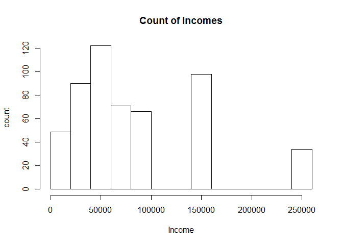

```r
#Create a simple histogram for two of these seven variables. Comment on the shape of the distribution in your markdown.
hist(ProcrastinationHdiData_18_or_older$Income, xlab="Income", ylab="count",  main="Count of Incomes")
```

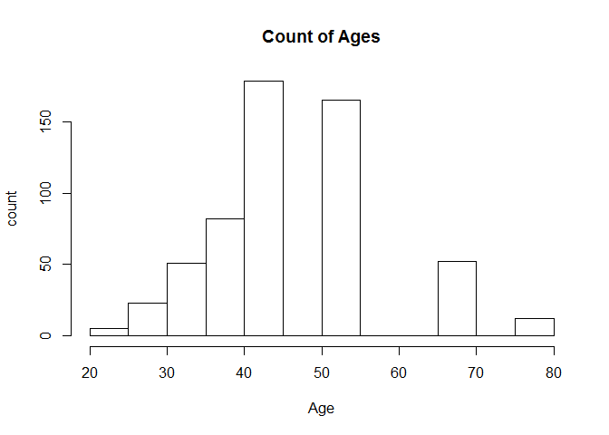

```r
hist(ProcrastinationHdiData_18_or_older$Age, xlab="Age", ylab="count",  main="Count of Ages")
```

For the ages we see a roughly normal distribution with a median/mode/mean around the 40-50 range. The extreme values are around 20 and 80, the min and max for the dataset.

```r
# c Give the frequencies (in table format or similar) for Gender, Work Status, and Occupation. They can be separate tables, if that's your choice.

ProcrastinationHdiData_18_or_older
```

[output not shown]

[output cut: 4537 more lines]

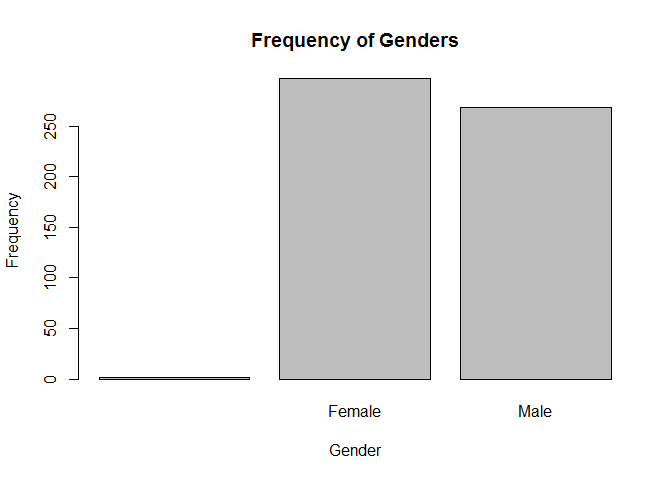

```r
barplot(height=table(ProcrastinationHdiData_18_or_older$Gender), xlab="Gender", ylab="Frequency",  main="Frequency of Genders")
```

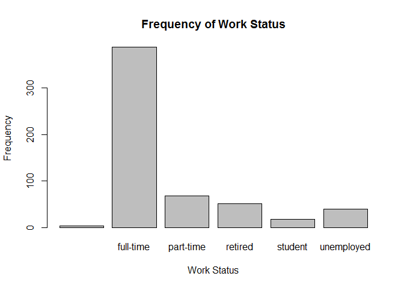

```r
barplot(height=table(ProcrastinationHdiData_18_or_older$WorkStatus), xlab="Work Status", ylab="Frequency",  main="Frequency of Work Status")
```

[figure not shown]

```r
barplot(height=table(ProcrastinationHdiData_18_or_older$Gender), xlab="Occupations", ylab="Frequency",  main="Frequency of Occupations")
```

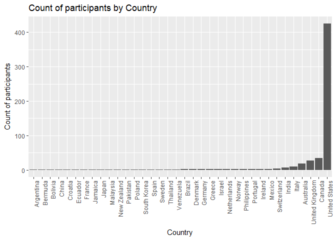

```r
# d Give the counts (again, pretty table) of how many participants per country in descending order.
ProcrastinationCountryPlot <- ggplot(data=ProcrastinationHdiData_18_or_older, aes(x=reorder(Country,Country,length)))
ProcrastinationCountryPlot <- ProcrastinationCountryPlot + geom_bar(aes(y = (..count..))) + scale_y_continuous() + theme(axis.text.x = element_text(angle = 90, hjust = 1))
ProcrastinationCountryPlot <- ProcrastinationCountryPlot + xlab("Country") + ylab("Count of participants") + ggtitle("Count of participants by Country")
print(ProcrastinationCountryPlot)
```

```r
# e There are two variables in the set: whether the person considers themselves a procrastinator (yes/no) and whether others consider them a procrastinator (yes/no). How many people matched their perceptions to others' (so, yes/yes and no/no)? To clarify: how many people said they felt they were procrastinators and also said others thought they were procrastinators? Likewise, how many said they were not procrastinators and others also did not think they were procrastinators?



yes_yes_match <- Procrastination_Raw_Data[which(ProcrastinationHdiData_18_or_older$Yourself == "yes" & ProcrastinationHdiData_18_or_older$Others == "yes"),]
no_no_match <- Procrastination_Raw_Data[which(ProcrastinationHdiData_18_or_older$Yourself == "no" & ProcrastinationHdiData_18_or_older$Others == "no"),]

#Get the number of matches from yes_yes_match
length(yes_yes_match$Yourself)
```

```
## [1] 308
```

```r
#Get the number of matches from no_no_match
length(no_no_match$Yourself)
```

```
## [1] 83
```

## Deeper Analysis and Visualization

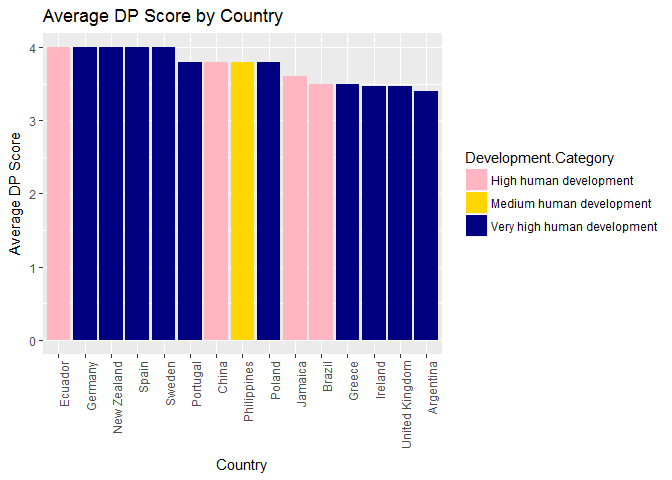

```r
# a Note: You should make all of these appealing looking. Remember to include things like a clean, informative title, axis labels that are in plain English, and readable axis values that do not overlap.


# b Create a barchart in ggplot or similar which displays the top 15 nations in average procrastination scores, using one measure of the following: DP, AIP, or GP. The bars should be in descending order, with the number 1 most procrastinating nation at the top and 15th most procrastinating at the bottom. Omit all other nations. Color the bars by HDI category (see 3B). Use any color palette of your choice other than the default.

#
# ProcrastinationCountryPlot <- ggplot(data=ProcrastinationHdiData_18_or_older, aes(x=reorder(Country,Country,length)))
# ProcrastinationCountryPlot <- ProcrastinationCountryPlot + geom_bar(aes(y = (..count..))) + scale_y_continuous() + theme(axis.text.x = element_text(angle = 90, hjust = 1))
# ProcrastinationCountryPlot <- ProcrastinationCountryPlot + xlab("Country") + ylab("Count of participants") + ggtitle("Count of participants by Country")
# print(ProcrastinationCountryPlot)


#Get the average DP Mean by country
CountryByDPMean <- ddply(ProcrastinationHdiData_18_or_older, c("Country"), summarise,DP_Mean = mean(DP_Mean))

#Create the order of the countries ranked by DP_Mean in a data frame and rename the column to Country
CountryByDPMeanOrdered <- CountryByDPMean$Country [order (CountryByDPMean$DP_Mean, decreasing = TRUE)]
CountryByDPMeanOrdered_df = data.frame(CountryByDPMeanOrdered)
CountryByDPMeanOrdered_df<-rename(CountryByDPMeanOrdered_df, c("CountryByDPMeanOrdered"="Country"))

#Merge the ordered data frame with the DP Mean data
CountryByDPMeanOrdered_df_merged = merge(CountryByDPMeanOrdered_df,CountryByDPMean,by.x = "Country", by.y = "Country",all.x=TRUE,sort=FALSE)
CountryByDPMeanTop15 = subset(CountryByDPMeanOrdered_df_merged, Country %in% CountryByDPMeanOrdered [1:15])

#Create an HDI Data Frame to merge with
CountryByHDICategory <- unique(ProcrastinationHdiData_18_or_older[,c('Country','Development.Category')])
CountryByDPMeanTop15Hdi <- merge(CountryByDPMeanTop15,CountryByHDICategory,by.x = "Country", by.y = "Country",all.x=TRUE,sort=FALSE)

#Plot the graph with custom colors ordering by DPMean
Custom_colors <- c("#ffb6c1", "#ffd700", "#000080", "#ff0000")
CountryByDPMeanTop15HdiPlot <- ggplot(data=CountryByDPMeanTop15Hdi, aes(x=reorder(Country, -DP_Mean), y=DP_Mean, fill=Development.Category))
CountryByDPMeanTop15HdiPlot <- CountryByDPMeanTop15HdiPlot + geom_bar(stat="identity") + theme(axis.text.x = element_text(angle = 90, hjust = 1))
CountryByDPMeanTop15HdiPlot <- CountryByDPMeanTop15HdiPlot + xlab("Country") + ylab("Average DP Score") + ggtitle("Average DP Score by Country")
CountryByDPMeanTop15HdiPlot <- CountryByDPMeanTop15HdiPlot + scale_fill_manual(values=Custom_colors)
print(CountryByDPMeanTop15HdiPlot)
```

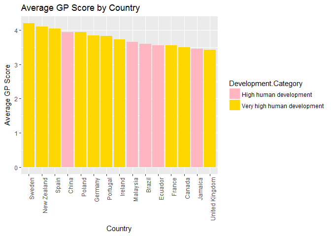

```r
# c Create another barchart identical in features to 5B, but use another one of the three variables: DP, AIP, or GP. How many nations show up both in 5B's plot and 5C's? Which, if any?
CountryByGPMean <- ddply(ProcrastinationHdiData_18_or_older, c("Country"), summarise,GP_Mean = mean(GP_Mean))

#Create the order of the countries ranked by GP_Mean in a data frame and rename the column to Country
CountryByGPMeanOrdered <- CountryByGPMean$Country [order (CountryByGPMean$GP_Mean, decreasing = TRUE)]
CountryByGPMeanOrdered_df = data.frame(CountryByGPMeanOrdered)
CountryByGPMeanOrdered_df<-rename(CountryByGPMeanOrdered_df, c("CountryByGPMeanOrdered"="Country"))

#Merge the ordered data frame with the GP Mean data
CountryByGPMeanOrdered_df_merged = merge(CountryByGPMeanOrdered_df,CountryByGPMean,by.x = "Country", by.y = "Country",all.x=TRUE,sort=FALSE)
CountryByGPMeanTop15 = subset(CountryByGPMeanOrdered_df_merged, Country %in% CountryByGPMeanOrdered [1:15])

#Create an HDI Data Frame to merge with
CountryByHDICategory <- unique(ProcrastinationHdiData_18_or_older[,c('Country','Development.Category')])
CountryByGPMeanTop15Hdi <- merge(CountryByGPMeanTop15,CountryByHDICategory,by.x = "Country", by.y = "Country",all.x=TRUE,sort=FALSE)

#Plot the graph with custom colors ordering by GPMean
Custom_colors <- c("#ffb6c1", "#ffd700", "#000080", "#ff0000")
CountryByGPMeanTop15HdiPlot <- ggplot(data=CountryByGPMeanTop15Hdi, aes(x=reorder(Country, -GP_Mean), y=GP_Mean, fill=Development.Category))
CountryByGPMeanTop15HdiPlot <- CountryByGPMeanTop15HdiPlot + geom_bar(stat="identity") + theme(axis.text.x = element_text(angle = 90, hjust = 1))
CountryByGPMeanTop15HdiPlot <- CountryByGPMeanTop15HdiPlot + xlab("Country") + ylab("Average GP Score") + ggtitle("Average GP Score by Country")
CountryByGPMeanTop15HdiPlot <- CountryByGPMeanTop15HdiPlot + scale_fill_manual(values=Custom_colors)
print(CountryByGPMeanTop15HdiPlot)
```

```r
CountryByGP_DPMeanTop15Hdi <- merge(CountryByGPMeanTop15Hdi,CountryByDPMeanTop15Hdi,by.x = "Country", by.y = "Country",all.x=FALSE,all.y=FALSE,sort=FALSE)

print(CountryByGP_DPMeanTop15Hdi$Country)
```

```
##  [1] Sweden         New Zealand    Spain          China
##  [5] Poland         Germany        Portugal       Ireland
##  [9] Brazil         Ecuador        Jamaica        United Kingdom
## 36 Levels: Argentina Australia Bermuda Bolivia Brazil Canada ... Venezuela
```

### These 12 countries are on both the top 15 DP and top 15 GP lists

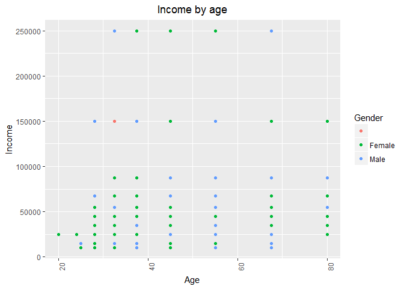

```r
# d Is there a relationship between Age and Income? Create a scatterplot and make an assessment of whether there is a relationship. Color each point based on the Gender of the participant. You're welcome to use lm() or similar functions to back up your claims.
AgeIncomePlot <- ggplot(data=ProcrastinationHdiData_18_or_older, aes(x=Age, y=Income, color=Gender))
AgeIncomePlot <- AgeIncomePlot + geom_point() + theme(axis.text.x = element_text(angle = 90, hjust = 1))
AgeIncomePlot <- AgeIncomePlot + xlab("Age") + ylab("Income") + ggtitle("Income by age")
AgeIncomePlot <- AgeIncomePlot + theme(plot.title = element_text(hjust = 0.5))

print(AgeIncomePlot)
```

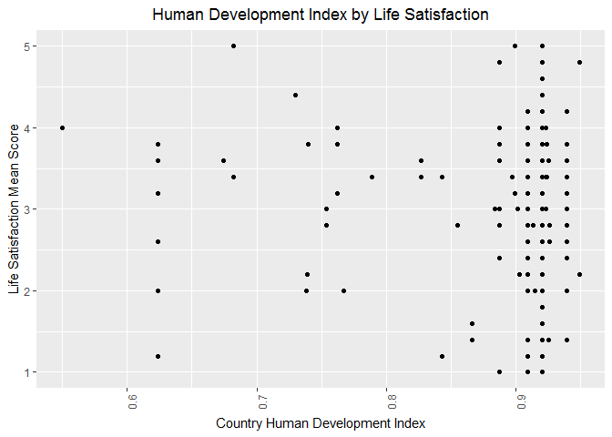

```r
# e What about Life Satisfaction and HDI? Create another scatterplot. Is there a discernible relationship there? What about if you used the HDI category instead and made a barplot?
SWLSMeanHdiPlot <- ggplot(data=ProcrastinationHdiData_18_or_older, aes(x=HDI, y=SWLS_Mean))
SWLSMeanHdiPlot <- SWLSMeanHdiPlot + geom_point() + theme(axis.text.x = element_text(angle = 90, hjust = 1))
SWLSMeanHdiPlot <- SWLSMeanHdiPlot + ylab("Life Satisfaction Mean Score") + xlab("Country Human Development Index") + ggtitle("Human Development Index by Life Satisfaction")
SWLSMeanHdiPlot <- SWLSMeanHdiPlot + theme(plot.title = element_text(hjust = 0.5))

print(SWLSMeanHdiPlot)
```

### The Life Satisfaction Score seems to be independant of the Country’s Human Development index, with a fairly even distribution of life satisfaction scores regardless of the HDI

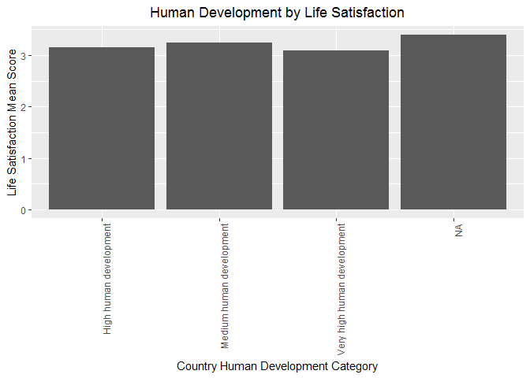

```r
HdiCategoryBySWLSMean <- ddply(ProcrastinationHdiData_18_or_older, c("Development.Category"), summarise,SWLS_Mean = mean(SWLS_Mean))


SWLSMeanHdiCategoryPlot <- ggplot(data=HdiCategoryBySWLSMean, aes(y=SWLS_Mean, x=Development.Category))
SWLSMeanHdiCategoryPlot <- SWLSMeanHdiCategoryPlot + geom_col() + theme(axis.text.x = element_text(angle = 90, hjust = 1))
SWLSMeanHdiCategoryPlot <- SWLSMeanHdiCategoryPlot + ylab("Life Satisfaction Mean Score") + xlab("Country Human Development Category") + ggtitle("Human Development by Life Satisfaction")
SWLSMeanHdiCategoryPlot <- SWLSMeanHdiCategoryPlot + theme(plot.title = element_text(hjust = 0.5))

print(SWLSMeanHdiCategoryPlot)
```

### Given the barchart there appears to be a slightly than higher average Life Satisfaction Score in countrie with a medium Human Development Index Category

## Outputting to CSV format - Make sure there are no index numbers

```r
# a The client would like the finalized HDI table (3A and 3B)
write.csv(hdiDataFrame_all, file = ".\\Paper\\FinalizedHdiTable.csv",row.names=FALSE)

# b The client would like the Tidied version of the original input to be output in the repository, including the merged HDI data (3C).
write.csv(ProcrastinationHdiData_18_or_older, file = ".\\Paper\\TidiedProcrastinationHdiData.csv",row.names=FALSE)

# c The client would like a dataset (or two) that shows the Top 15 nations (in 5B and 5C), as well as their HDI scores.
write.csv(CountryByDPMeanTop15Hdi, file = ".\\Paper\\Top15CountriesByDpWithHdi.csv",row.names=FALSE)
write.csv(CountryByGPMeanTop15Hdi, file = ".\\Paper\\Top15CountriesByGpWithHdi.csv",row.names=FALSE)

# d All output should be in plain English or translated in the Codebook.
```

## Conclusion

Greetings Nintendo Marketing Team,

From our analysis we provided you the 12 laziest countries: Sweden, New Zealand, Spain, China, Poland, Germany, Portugal, Ireland, Brazil, Ecuador, Jamaica, United Kingdom

From this list, the countries with a very high Human Development index are: Sweden, New Zealand, Spain, Poland, Germany, Portugal, Ireland, and United Kingdom

We deduce that the Very Highly Developed and very highly procrastinating humans in these countries would be ideal cadidates for Nintendo marketing. Please let us knwo if you find our services valuable and would like to invest in more information now and in the future.

Thank you,

Brian Coari, Gergory Asamoah, and Emil Ramos

LazyLife Inc.

Email: datascience@lazylife.com

Phone: (555) 867-5309